# Brain Tumor Transcriptomic Biomarker Discovery and Differential Gene Expression Analysis

## Introduction

Brain tumors represent a highly heterogeneous group of neurological malignancies characterized by abnormal cellular proliferation within the central nervous system. Among these, gliomas constitute one of the most aggressive and clinically challenging tumor classes due to their infiltrative growth behavior, molecular complexity, and poor therapeutic prognosis. Accurate characterization of tumor-associated molecular alterations is therefore essential for improving diagnosis, understanding disease progression, and identifying potential therapeutic targets.

Advances in high-throughput transcriptomic technologies have enabled large-scale investigation of gene expression patterns associated with tumor initiation, progression, and microenvironmental dysregulation. Gene expression profiling allows systematic identification of differentially expressed genes (DEGs), dysregulated biological pathways, and candidate molecular biomarkers associated with pathological states.

In this study, transcriptomic analysis was performed using publicly available human brain tumor microarray expression data obtained from the Gene Expression Omnibus (GEO) repository. The dataset contains expression profiles from multiple brain tumor subtypes along with non-tumor control samples, enabling comparative investigation of tumor-associated molecular signatures.

The primary objectives of this analysis include:

- preprocessing and organization of transcriptomic expression data
- identification of differentially expressed genes between tumor and non-tumor samples
- investigation of biologically significant molecular alterations
- visualization of transcriptomic patterns through exploratory analysis
- identification of candidate biomarkers associated with brain tumor pathology

This transcriptomic workflow complements the MRI-based radiomic and deep learning imaging analysis performed previously within the project. While imaging analysis characterizes structural and radiographic tumor phenotypes, transcriptomic profiling provides insight into the underlying molecular dysregulation contributing to tumor-associated biological behavior.

The integration of imaging-derived phenotypic characterization with transcriptomic biomarker discovery strengthens the overall computational neuro-oncology framework and contributes toward a more comprehensive understanding of brain tumor biology.

# 1. Transcriptomic Data Loading and Initial Exploration

## Objective

The first stage of the transcriptomic workflow involves loading and organizing the brain tumor gene expression dataset along with associated metadata and platform annotations.

Proper preprocessing and validation of transcriptomic datasets are essential before performing downstream analyses such as:

- differential gene expression analysis
- biomarker identification
- pathway enrichment analysis
- transcriptomic visualization
- molecular characterization of tumor-associated biological alterations

The current dataset contains microarray-based gene expression profiles derived from human brain tumor and non-tumor tissue samples obtained from the GEO database (GSE4290).

The dataset includes:

- probe identifiers
- gene symbols
- gene annotations
- expression measurements across multiple brain tumor subtypes
- corresponding sample diagnostic labels

Initial exploratory analysis is performed to verify dataset integrity, inspect dimensional structure, and prepare the expression matrix for downstream bioinformatics analysis.

```python
import pandas as pd
import numpy as np

# Load datasets

expression_df = pd.read_csv('/kaggle/input/datasets/somshirsha/brain-cancer/Copy of Brain Cancer.csv')

metadata_df = pd.read_csv('/kaggle/input/datasets/somshirsha/brain-cancer/GSE4290_metadata.csv')

annotation_df = pd.read_csv('/kaggle/input/datasets/somshirsha/brain-cancer/GPL570_clean.csv')

import numpy as np # linear algebra
import pandas as pd # data processing, CSV file I/O (e.g. pd.read_csv)
```

```python
# Check dataset dimensions

print("Expression Dataset Shape:", expression_df.shape)
print("Metadata Shape:", metadata_df.shape)
print("Annotation Dataset Shape:", annotation_df.shape)
```

```
Expression Dataset Shape: (54635, 183)
Metadata Shape: (180, 2)
Annotation Dataset Shape: (54675, 3)
```

```python
# Preview expression matrix
expression_df.head()
```

|  | ID_REF | Gene Symbol | Gene Title | astrocytoma, grade 3 | glioblastoma, grade 4 | astrocytoma, grade 3.1 | glioblastoma, grade 4.1 | glioblastoma, grade 4.2 | glioblastoma, grade 4.3 | oligodendroglioma, grade 2 | ... | glioblastoma, grade 4.70 | oligodendroglioma, grade 2.36 | glioblastoma, grade 4.71 | glioblastoma, grade 4.72 | glioblastoma, grade 4.73 | glioblastoma, grade 4.74 | glioblastoma, grade 4.75 | oligodendroglioma, grade 2.37 | glioblastoma, grade 4.76 | astrocytoma, grade 2.6 |
| --- | --- | --- | --- | --- | --- | --- | --- | --- | --- | --- | --- | --- | --- | --- | --- | --- | --- | --- | --- | --- | --- |
| 0 | 1007_s_at | DDR1 /// MIR4640 | discoidin domain receptor tyrosine kinase 1 //... | NaN | NaN | NaN | NaN | NaN | NaN | NaN | ... | NaN | NaN | NaN | NaN | NaN | NaN | NaN | NaN | NaN | NaN |
| 1 | 1053_at | RFC2 | replication factor C (activator 1) 2, 40kDa | 388.2 | 517.5 | 352.4 | 609.9 | 430.1 | 592.5 | 378.9 | ... | 1229.4 | 424.0 | 1023.8 | 951.7 | 358.1 | 338.3 | 501.2 | 390.3 | 606.2 | 286.9 |
| 2 | 117_at | HSPA6 | heat shock 70kDa protein 6 (HSP70B') | 227.3 | 460.7 | 306.0 | 629.7 | 551.6 | 393.6 | 200.4 | ... | 245.4 | 199.8 | 634.0 | 239.3 | 236.3 | 232.9 | 307.1 | 154.8 | 486.1 | 167.8 |
| 3 | 121_at | PAX8 | paired box 8 | 1665.4 | 1754.1 | 1967.0 | 1521.8 | 1714.5 | 1702.0 | 1552.9 | ... | 1248.2 | 1294.2 | 1416.6 | 1198.4 | 1712.3 | 1500.8 | 1685.8 | 1580.5 | 1620.0 | 1398.6 |
| 4 | 1255_g_at | GUCA1A | guanylate cyclase activator 1A (retina) | 90.7 | 69.1 | 106.4 | 39.7 | 57.3 | 54.9 | 60.1 | ... | 36.1 | 75.2 | 14.3 | 52.6 | 162.5 | 174.4 | 46.0 | 102.5 | 134.4 | 54.9 |

5 rows × 183 columns

## Initial Dataset Overview

The transcriptomic expression matrix contains probe-level microarray measurements corresponding to multiple human brain tumor samples and non-tumor controls.

Each row represents an individual probe associated with a gene or transcript, while columns correspond to independent biological samples. Gene symbols and descriptive gene annotations are included to facilitate downstream biological interpretation. The metadata table contains diagnostic information for each sample and will be utilized to define tumor and non-tumor comparison groups during differential expression analysis. Initial inspection of the dataset structure is important for identifying:

- missing annotations
- duplicated gene symbols
- inconsistent formatting
- non-expression columns
- preprocessing requirements prior to statistical analysis

```python
# Check missing values

print(expression_df.isnull().sum().head(10))
```

```
ID_REF                          22
Gene Symbol                   8853
Gene Title                    9955
astrocytoma, grade 3            23
glioblastoma, grade 4           23
astrocytoma, grade 3.1          23
glioblastoma, grade 4.1         23
glioblastoma, grade 4.2         23
glioblastoma, grade 4.3         23
oligodendroglioma, grade 2      23
dtype: int64
```

```python
# Remove rows with missing Gene Symbol
expression_df = expression_df.dropna(
    subset=['Gene Symbol']
)
# Remove rows with missing Gene Title
expression_df = expression_df.dropna(
    subset=['Gene Title']
)
# Remove rows with missing expression values
expression_df = expression_df.dropna()
# Reset index
expression_df = expression_df.reset_index(drop=True)
# Check updated shape
print("Updated Dataset Shape:", expression_df.shape)
```

```
Updated Dataset Shape: (44669, 183)
```

```python
# Verify missing values after cleaning

print(expression_df.isnull().sum().head(10))
```

```
ID_REF                        0
Gene Symbol                   0
Gene Title                    0
astrocytoma, grade 3          0
glioblastoma, grade 4         0
astrocytoma, grade 3.1        0
glioblastoma, grade 4.1       0
glioblastoma, grade 4.2       0
glioblastoma, grade 4.3       0
oligodendroglioma, grade 2    0
dtype: int64
```

```python
# Inspect metadata

metadata_df['Diagnosis'].value_counts()
```

```
Diagnosis
glioblastoma, grade 4         77
oligodendroglioma, grade 2    38
non-tumor                     23
astrocytoma, grade 3          19
oligodendroglioma, grade 3    12
astrocytoma, grade 2           7
Unknown                        4
Name: count, dtype: int64
```

### Extract Expression Columns

```python
# Separate annotation columns

annotation_columns = [

    'ID_REF',

    'Gene Symbol',

    'Gene Title'
]

# Extract expression matrix

expression_values = expression_df.drop(

    columns=annotation_columns
)

print(expression_values.shape)
```

```
(44669, 180)
```

# 2. Alignment of Transcriptomic Expression Matrix with Metadata Labels

## Objective

Before performing differential gene expression analysis, it is essential to ensure that transcriptomic expression measurements are correctly aligned with their corresponding biological sample annotations.

The expression matrix contains gene expression values across multiple samples, whereas the metadata table contains diagnostic labels describing the pathological status of each sample. Proper alignment guarantees that each expression profile is accurately associated with its respective tumor or non-tumor condition.

This preprocessing stage is critically important because incorrect sample alignment may lead to:

- biologically invalid statistical comparisons
- inaccurate differential expression results
- misleading biomarker identification
- improper downstream pathway interpretation

```python
# View first few expression columns
expression_df.columns[:10]
```

```
Index(['ID_REF', 'Gene Symbol', 'Gene Title', 'astrocytoma, grade 3',
       'glioblastoma, grade 4', 'astrocytoma, grade 3.1',
       'glioblastoma, grade 4.1', 'glioblastoma, grade 4.2',
       'glioblastoma, grade 4.3', 'oligodendroglioma, grade 2'],
      dtype='object')
```

```python
# Define annotation columns
annotation_columns = [
    'ID_REF',
    'Gene Symbol',
    'Gene Title'
]
# Extract sample columns
sample_columns = [
    col for col in expression_df.columns
    if col not in annotation_columns
]
print("Total Sample Columns:", len(sample_columns))
```

```
Total Sample Columns: 180
```

```python
# Preview metadata
metadata_df.head()
```

|  | Sample_ID | Diagnosis |
| --- | --- | --- |
| 0 | GSM97793 | astrocytoma, grade 3 |
| 1 | GSM97794 | glioblastoma, grade 4 |
| 2 | GSM97795 | astrocytoma, grade 3 |
| 3 | GSM97796 | glioblastoma, grade 4 |
| 4 | GSM97797 | glioblastoma, grade 4 |

```python
# Find common sample IDs
common_samples = list(
    set(sample_columns).intersection(
        set(metadata_df['Sample_ID'])
    )
)
print("Common Samples:", len(common_samples))
```

```
Common Samples: 0
```

## Identification of Shared Sample Identifiers

```python
# Check duplicate expression column names

duplicate_columns = expression_df.columns[

    expression_df.columns.duplicated()
]

print("Total Duplicate Columns:", len(duplicate_columns))
```

```
Total Duplicate Columns: 0
```

```python
# Preview duplicate names

print(duplicate_columns[:20])
```

```
Index([], dtype='object')
```

# 3. Gene-Level Transcriptomic Preprocessing

## Objective

Microarray datasets frequently contain multiple probes corresponding to the same gene symbol. Because downstream biological interpretation is generally performed at the gene level rather than the probe level, transcriptomic preprocessing requires consolidation of duplicated probe measurements.

Additionally, incomplete or ambiguous gene annotations may introduce redundancy and statistical noise during downstream differential expression analysis.

The current preprocessing stage therefore focuses on:

- removal of invalid annotations
- elimination of duplicated gene symbols
- aggregation of multiple probes mapping to identical genes
- construction of a clean gene-level expression matrix

This step improves biological interpretability and enhances the reliability of downstream biomarker discovery analyses.

```python
# Remove empty gene symbols

expression_df = expression_df[

    expression_df['Gene Symbol'].str.strip() != ''
]

print(expression_df.shape)
```

```
(44669, 183)
```

```python
# Count duplicated gene symbols

duplicate_genes = expression_df[

    'Gene Symbol'
].duplicated().sum()

print("Duplicated Gene Symbols:", duplicate_genes)
```

```
Duplicated Gene Symbols: 22172
```

## Identification of Duplicate Gene Symbols

Microarray platforms commonly contain multiple probes corresponding to the same gene or transcript. As a result, duplicate gene symbols are expected within the expression matrix.

Such redundancy may arise because:

- different probes target distinct transcript regions
- multiple probe sets exist for validation purposes
- transcript isoforms share overlapping annotations

To improve biological interpretability, probe-level redundancy will be reduced by aggregating probes sharing identical gene symbols into unified gene-level expression profiles.

```python
# Group by Gene Symbol and compute mean expression

gene_expression_df = expression_df.groupby(

    'Gene Symbol'
).mean(numeric_only=True)

print(gene_expression_df.shape)
```

```
(22497, 180)
```

```python
# Preview processed gene-level matrix

gene_expression_df.head()
```

| Gene Symbol | astrocytoma, grade 3 | glioblastoma, grade 4 | astrocytoma, grade 3.1 | glioblastoma, grade 4.1 | glioblastoma, grade 4.2 | glioblastoma, grade 4.3 | oligodendroglioma, grade 2 | non-tumor | glioblastoma, grade 4.4 | astrocytoma, grade 3.2 | ... | glioblastoma, grade 4.70 | oligodendroglioma, grade 2.36 | glioblastoma, grade 4.71 | glioblastoma, grade 4.72 | glioblastoma, grade 4.73 | glioblastoma, grade 4.74 | glioblastoma, grade 4.75 | oligodendroglioma, grade 2.37 | glioblastoma, grade 4.76 | astrocytoma, grade 2.6 |
| --- | --- | --- | --- | --- | --- | --- | --- | --- | --- | --- | --- | --- | --- | --- | --- | --- | --- | --- | --- | --- | --- |
| A1BG | 240.60 | 194.2 | 162.10 | 74.8 | 194.50 | 117.0 | 64.30 | 173.70 | 178.00 | 128.20 | ... | 190.9 | 100.4 | 90.10 | 197.9 | 119.3 | 190.00 | 188.30 | 116.60 | 237.90 | 148.40 |
| A1BG-AS1 | 22.70 | 24.5 | 23.70 | 56.5 | 25.70 | 23.8 | 30.40 | 77.40 | 32.90 | 17.20 | ... | 15.4 | 28.1 | 14.00 | 14.6 | 34.5 | 82.40 | 18.20 | 24.10 | 18.90 | 46.90 |
| A1CF | 297.40 | 205.2 | 173.25 | 160.0 | 203.65 | 176.5 | 199.70 | 179.50 | 147.05 | 150.75 | ... | 88.7 | 172.3 | 145.40 | 166.9 | 203.9 | 161.95 | 313.80 | 220.10 | 123.25 | 136.60 |
| A2M | 3034.55 | 5136.2 | 2670.70 | 10557.8 | 8181.95 | 4188.8 | 2966.75 | 1344.65 | 6705.25 | 4052.10 | ... | 6924.8 | 2605.3 | 10097.55 | 9156.7 | 2704.7 | 2073.40 | 8114.55 | 2713.85 | 5825.95 | 4099.45 |
| A2M-AS1 | 353.00 | 220.0 | 238.40 | 162.3 | 312.90 | 169.8 | 232.00 | 202.80 | 201.60 | 162.90 | ... | 131.9 | 149.9 | 121.60 | 144.1 | 244.0 | 216.00 | 299.90 | 367.70 | 444.60 | 452.20 |

5 rows × 180 columns

# 4. Construction of Tumor and Non-Tumor Expression Groups

## Objective

To identify transcriptomic alterations associated with brain tumor pathology, the processed gene-level expression matrix was separated into tumor and non-tumor groups based on sample diagnostic annotations embedded within the expression column names.

This grouping strategy enables comparative statistical analysis between pathological and control brain tissue samples for the identification of differentially expressed genes (DEGs).

The resulting DEG analysis aims to identify:

- upregulated tumor-associated genes
- downregulated molecular signatures
- biologically significant transcriptomic alterations
- candidate biomarkers associated with tumor progression

Such molecular profiling provides insight into the transcriptomic dysregulation underlying brain tumor biology.

```python
# Identify tumor and non-tumor columns

tumor_columns = [

    col for col in gene_expression_df.columns

    if 'non-tumor' not in col.lower()
]

non_tumor_columns = [

    col for col in gene_expression_df.columns

    if 'non-tumor' in col.lower()
]

print("Tumor Samples:", len(tumor_columns))

print("Non-Tumor Samples:", len(non_tumor_columns))
```

```
Tumor Samples: 157
Non-Tumor Samples: 23
```

```python
# Create separate expression matrices

tumor_expr = gene_expression_df[tumor_columns]

non_tumor_expr = gene_expression_df[non_tumor_columns]

print(tumor_expr.shape)

print(non_tumor_expr.shape)
```

```
(22497, 157)
(22497, 23)
```

## Preparation of Differential Expression Inputs

The transcriptomic dataset was divided into tumor-associated and non-tumor expression groups to facilitate comparative statistical analysis.

Tumor samples included multiple pathological brain tumor subtypes such as:

- glioblastoma
- astrocytoma
- oligodendroglioma

Non-tumor samples served as biological controls representing comparatively normal brain tissue expression profiles.

This binary grouping framework improves statistical robustness during the initial stage of differential gene expression analysis and enables identification of broad molecular alterations associated with tumor pathology.

# 5. Differential Gene Expression Analysis

## Objective

Differential gene expression analysis was performed to identify genes exhibiting statistically significant expression differences between tumor and non-tumor brain tissue samples.

Genes demonstrating substantial transcriptomic dysregulation may represent:

- tumor-associated molecular signatures
- oncogenic pathways
- candidate diagnostic biomarkers
- potential therapeutic targets

For each gene, statistical analysis included:

- calculation of mean expression values
- estimation of log2 fold change
- independent two-sample t-test
- assessment of statistical significance

Genes exhibiting large expression changes and significant p-values were considered potential differentially expressed genes (DEGs).

```python
from scipy.stats import ttest_ind
```

```python
# Store DEG results

deg_results = []

# Iterate through genes

for gene in gene_expression_df.index:

    tumor_values = tumor_expr.loc[gene]

    non_tumor_values = non_tumor_expr.loc[gene]

    # Mean expression

    tumor_mean = np.mean(tumor_values)

    non_tumor_mean = np.mean(non_tumor_values)

    # Log2 Fold Change

    log2_fc = np.log2(

        (tumor_mean + 1e-6) /

        (non_tumor_mean + 1e-6)
    )

    # T-test

    t_stat, p_value = ttest_ind(

        tumor_values,

        non_tumor_values,

        equal_var=False
    )

    # Save results

    deg_results.append([

        gene,

        tumor_mean,

        non_tumor_mean,

        log2_fc,

        p_value
    ])
```

```python
# Convert DEG results into dataframe

deg_df = pd.DataFrame(
    deg_results,
    columns=[
        'Gene',
        'Tumor_Mean',
        'NonTumor_Mean',
        'Log2FC',
        'P_Value'
    ]
)
deg_df.head()
```

|  | Gene | Tumor_Mean | NonTumor_Mean | Log2FC | P_Value |
| --- | --- | --- | --- | --- | --- |
| 0 | A1BG | 156.352229 | 170.339130 | -0.123610 | 3.232966e-01 |
| 1 | A1BG-AS1 | 38.262420 | 55.913043 | -0.547257 | 3.140014e-02 |
| 2 | A1CF | 176.069745 | 186.341304 | -0.081800 | 4.552469e-01 |
| 3 | A2M | 5138.978344 | 3025.147826 | 0.764476 | 4.139141e-12 |
| 4 | A2M-AS1 | 234.487898 | 222.752174 | 0.074074 | 3.456711e-01 |

```python
from statsmodels.stats.multitest import multipletests
```

```python
# Adjust p-values using FDR correction
deg_df['Adjusted_P_Value'] = multipletests(
    deg_df['P_Value'],
    method='fdr_bh'
)[1]
deg_df.head()
```

|  | Gene | Tumor_Mean | NonTumor_Mean | Log2FC | P_Value | Adjusted_P_Value |
| --- | --- | --- | --- | --- | --- | --- |
| 0 | A1BG | 156.352229 | 170.339130 | -0.123610 | 3.232966e-01 | 4.045838e-01 |
| 1 | A1BG-AS1 | 38.262420 | 55.913043 | -0.547257 | 3.140014e-02 | 5.233479e-02 |
| 2 | A1CF | 176.069745 | 186.341304 | -0.081800 | 4.552469e-01 | 5.391990e-01 |
| 3 | A2M | 5138.978344 | 3025.147826 | 0.764476 | 4.139141e-12 | 3.711370e-11 |
| 4 | A2M-AS1 | 234.487898 | 222.752174 | 0.074074 | 3.456711e-01 | 4.278714e-01 |

```python
# Define significance thresholds
significant_deg = deg_df[
    (abs(deg_df['Log2FC']) > 1) &
    (deg_df['Adjusted_P_Value'] < 0.05)
]
print("Significant DEGs:", significant_deg.shape[0])
```

```
Significant DEGs: 2548
```

# 6. Volcano Plot Visualization of Differentially Expressed Genes

## Objective

Volcano plot analysis was performed to visualize the global distribution of transcriptomic alterations between tumor and non-tumor brain tissue samples.

The volcano plot simultaneously represents:

- magnitude of expression change (log2 fold change)
- statistical significance (-log10 adjusted p-value)

This visualization enables rapid identification of highly dysregulated genes exhibiting both large expression differences and strong statistical significance.

Genes positioned toward the upper left and upper right regions of the volcano plot represent the most biologically significant differentially expressed genes and may serve as candidate biomarkers associated with brain tumor pathology.

```python
# Compute negative log10 adjusted p-values

deg_df['NegLog10P'] = -np.log10(

    deg_df['Adjusted_P_Value'] + 1e-300
)
```

```python
# Define DEG categories

deg_df['Category'] = 'Not Significant'

deg_df.loc[

    (deg_df['Log2FC'] > 1) &

    (deg_df['Adjusted_P_Value'] < 0.05),

    'Category'

] = 'Upregulated'

deg_df.loc[

    (deg_df['Log2FC'] < -1) &

    (deg_df['Adjusted_P_Value'] < 0.05),

    'Category'

] = 'Downregulated'
```

```python
import seaborn as sns
import matplotlib.pyplot as plt
```

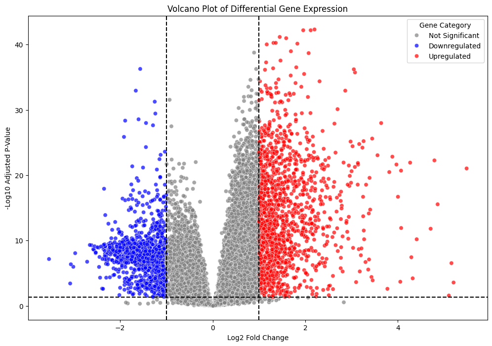

```python
# Volcano plot

plt.figure(figsize=(12, 8))
sns.scatterplot(
    data=deg_df,
    x='Log2FC',
    y='NegLog10P',
    hue='Category',
    palette={
        'Upregulated': 'red',
        'Downregulated': 'blue',
        'Not Significant': 'gray'
    },
    alpha=0.7
)
# Threshold lines
plt.axvline(
    x=1,
    linestyle='--',
    color='black'
)
plt.axvline(
    x=-1,
    linestyle='--',
    color='black'
)
plt.axhline(
    y=-np.log10(0.05),
    linestyle='--',
    color='black'
)
plt.title(
    'Volcano Plot of Differential Gene Expression'
)
plt.xlabel('Log2 Fold Change')
plt.ylabel('-Log10 Adjusted P-Value')
plt.legend(title='Gene Category')
plt.show()
```

## Interpretation of Volcano Plot Analysis

The volcano plot illustrates the global transcriptomic landscape associated with brain tumor pathology by simultaneously representing expression magnitude (log2 fold change) and statistical significance (-log10 adjusted p-value) for all analyzed genes.

Genes positioned toward the right side of the plot represent significantly upregulated transcripts in tumor samples relative to non-tumor controls, whereas genes positioned toward the left side represent significantly downregulated transcripts.

The analysis revealed a substantial number of statistically significant differentially expressed genes, indicating widespread transcriptomic dysregulation associated with brain tumor progression and pathological transformation.

Several strongly upregulated genes exhibited both high positive log2 fold change and elevated statistical significance, suggesting activation of tumor-associated molecular pathways related to:

- uncontrolled cellular proliferation
- oncogenic signaling
- extracellular matrix remodeling
- metabolic adaptation
- invasion and tumor progression

Similarly, significantly downregulated genes may correspond to:

- neuronal function suppression
- disrupted tissue homeostasis
- loss of normal neurophysiological activity
- altered cellular differentiation states

The characteristic volcano-shaped distribution further demonstrates clear molecular separation between tumor and non-tumor transcriptomic profiles, supporting the biological validity of the differential expression analysis.

Importantly, the presence of highly significant genes with large fold-change magnitudes suggests the existence of potential transcriptomic biomarkers associated with brain tumor pathology and progression.

# 7. Identification of Candidate Differentially Expressed Biomarkers

## Objective

To identify potential molecular biomarkers associated with brain tumor pathology, the most significantly dysregulated genes were extracted from the differential expression analysis results.

Genes exhibiting:

- large fold-change magnitude
- strong statistical significance
- consistent tumor-associated dysregulation

may represent biologically relevant candidate biomarkers involved in tumor progression, cellular proliferation, invasion, and pathological signaling pathways.

Both upregulated and downregulated genes were investigated separately to characterize transcriptomic alterations associated with malignant transformation.

```python
# Top upregulated genes
top_upregulated = deg_df.sort_values(
    by='Log2FC',
    ascending=False
).head(20)
top_upregulated
```

|  | Gene | Tumor_Mean | NonTumor_Mean | Log2FC | P_Value | Adjusted_P_Value | NegLog10P | Category |
| --- | --- | --- | --- | --- | --- | --- | --- | --- |
| 20424 | TOP2A | 587.836730 | 13.101449 | 5.487617 | 1.972357e-23 | 9.224971e-22 | 21.035035 | Upregulated |
| 17580 | SAA1 /// SAA2 | 625.182803 | 16.943478 | 5.205476 | 1.025597e-04 | 2.659388e-04 | 3.575218 | Upregulated |
| 12541 | LTF | 3015.644586 | 84.356522 | 5.159823 | 6.792006e-08 | 2.860883e-07 | 6.543500 | Upregulated |
| 8608 | IGH /// IGHA1 /// IGHA2 | 350.212102 | 10.182609 | 5.104050 | 1.470082e-02 | 2.631060e-02 | 1.579869 | Upregulated |
| 8595 | IGFBP2 | 6047.814650 | 208.104348 | 4.861035 | 1.458214e-17 | 2.845224e-16 | 15.545884 | Upregulated |
| 13989 | NDC80 | 264.392994 | 9.547826 | 4.791368 | 9.338397e-25 | 5.428577e-23 | 22.265314 | Upregulated |
| 17907 | SERPINH1 | 749.956051 | 28.647826 | 4.710308 | 1.392769e-13 | 1.550378e-12 | 11.809562 | Upregulated |
| 3940 | CNGA3 | 302.842675 | 14.260870 | 4.408435 | 7.483197e-12 | 6.415758e-11 | 10.192752 | Upregulated |
| 2635 | C7orf57 | 172.164331 | 8.608696 | 4.321848 | 2.131325e-05 | 6.100307e-05 | 4.214648 | Upregulated |
| 12974 | MEOX2 | 260.355732 | 13.278261 | 4.293346 | 7.145066e-09 | 3.580012e-08 | 7.446115 | Upregulated |
| 12971 | MELK | 482.645223 | 25.073913 | 4.266704 | 2.178026e-24 | 1.198021e-22 | 21.921536 | Upregulated |
| 15649 | PLEKHA4 | 238.799363 | 14.191304 | 4.072720 | 1.060941e-13 | 1.204846e-12 | 11.919068 | Upregulated |
| 4279 | CRNDE | 799.080573 | 47.567391 | 4.070296 | 4.478162e-23 | 1.998913e-21 | 20.699206 | Upregulated |
| 17581 | SAA1 /// SAA2 /// SAA2-SAA4 | 254.024204 | 15.291304 | 4.054182 | 7.676229e-05 | 2.024764e-04 | 3.693626 | Upregulated |
| 6817 | FOXM1 | 295.670064 | 18.430435 | 4.003826 | 8.651196e-19 | 2.008524e-17 | 16.697123 | Upregulated |
| 19953 | TIMP4 | 2117.530573 | 135.008696 | 3.971259 | 4.540736e-24 | 2.311152e-22 | 21.636171 | Upregulated |
| 9402 | KIF20A | 276.891083 | 18.769565 | 3.882851 | 2.173855e-25 | 1.459857e-23 | 22.835690 | Upregulated |
| 15070 | PBK | 670.675796 | 47.608696 | 3.816319 | 7.841201e-23 | 3.334660e-21 | 20.476948 | Upregulated |
| 12060 | LOC286178 | 428.617197 | 31.291304 | 3.775856 | 1.108802e-03 | 2.441492e-03 | 2.612345 | Upregulated |
| 21114 | UHRF1 | 1951.770064 | 156.478261 | 3.640749 | 5.114522e-31 | 1.046013e-28 | 27.980463 | Upregulated |

```python
# Top downregulated genes

top_downregulated = deg_df.sort_values(

    by='Log2FC',

    ascending=True
).head(20)

top_downregulated
```

|  | Gene | Tumor_Mean | NonTumor_Mean | Log2FC | P_Value | Adjusted_P_Value | NegLog10P | Category |
| --- | --- | --- | --- | --- | --- | --- | --- | --- |
| 18349 | SLC30A3 | 58.894904 | 683.743478 | -3.537240 | 1.423212e-08 | 6.766272e-08 | 7.169651 | Downregulated |
| 15282 | PDYN | 126.112739 | 1066.017391 | -3.079445 | 1.465610e-04 | 3.711789e-04 | 3.430417 | Downregulated |
| 3568 | CES4A | 66.300000 | 554.686957 | -3.064593 | 1.053154e-07 | 4.291396e-07 | 6.367401 | Downregulated |
| 1725 | BC035096 /// RP11-433J8.1 | 26.314650 | 212.260870 | -3.011900 | 2.706641e-07 | 1.036624e-06 | 5.984379 | Downregulated |
| 2759 | CACNG3 | 248.870701 | 1951.765217 | -2.971311 | 1.514996e-09 | 8.589432e-09 | 8.066036 | Downregulated |
| 14110 | NEUROD6 | 249.040764 | 1632.947826 | -2.713025 | 3.967764e-08 | 1.739676e-07 | 6.759532 | Downregulated |
| 19127 | SST | 658.456688 | 4144.439130 | -2.654016 | 6.583440e-11 | 4.788479e-10 | 9.319802 | Downregulated |
| 4194 | CPNE6 | 169.798089 | 1041.208696 | -2.616367 | 7.267857e-11 | 5.240544e-10 | 9.280624 | Downregulated |
| 6192 | FAM19A1 | 473.612739 | 2831.295652 | -2.579683 | 3.386366e-10 | 2.175416e-09 | 8.662458 | Downregulated |
| 902 | ANO3 | 291.309554 | 1720.386957 | -2.562108 | 4.299038e-10 | 2.711395e-09 | 8.566807 | Downregulated |
| 12679 | MAL2 | 455.947134 | 2669.965217 | -2.549882 | 1.085471e-10 | 7.626430e-10 | 9.117679 | Downregulated |
| 4797 | DDN | 448.802548 | 2590.982609 | -2.529347 | 1.463677e-09 | 8.313140e-09 | 8.080235 | Downregulated |
| 14670 | OLFM3 | 202.298726 | 1165.773913 | -2.526729 | 1.159222e-09 | 6.719664e-09 | 8.172652 | Downregulated |
| 17915 | SERTM1 | 243.359236 | 1366.960870 | -2.489813 | 1.586527e-10 | 1.082891e-09 | 8.965415 | Downregulated |
| 5847 | ERC2 | 677.187261 | 3734.821739 | -2.463413 | 1.811965e-10 | 1.224873e-09 | 8.911909 | Downregulated |
| 14690 | OPALIN | 900.817197 | 4940.469565 | -2.455342 | 2.879810e-07 | 1.099017e-06 | 5.958995 | Downregulated |
| 6989 | GABRA5 | 283.783227 | 1546.678261 | -2.446312 | 6.544448e-09 | 3.303353e-08 | 7.481045 | Downregulated |
| 12868 | MCHR2 | 27.678981 | 149.491304 | -2.433199 | 1.647513e-05 | 4.803538e-05 | 4.318439 | Downregulated |
| 19427 | SYNPR | 1304.909554 | 6963.813043 | -2.415928 | 1.166099e-10 | 8.147118e-10 | 9.088996 | Downregulated |
| 10455 | LIPA /// LOC101926887 | 31.712102 | 166.121739 | -2.389135 | 1.026999e-03 | 2.273384e-03 | 2.643327 | Downregulated |

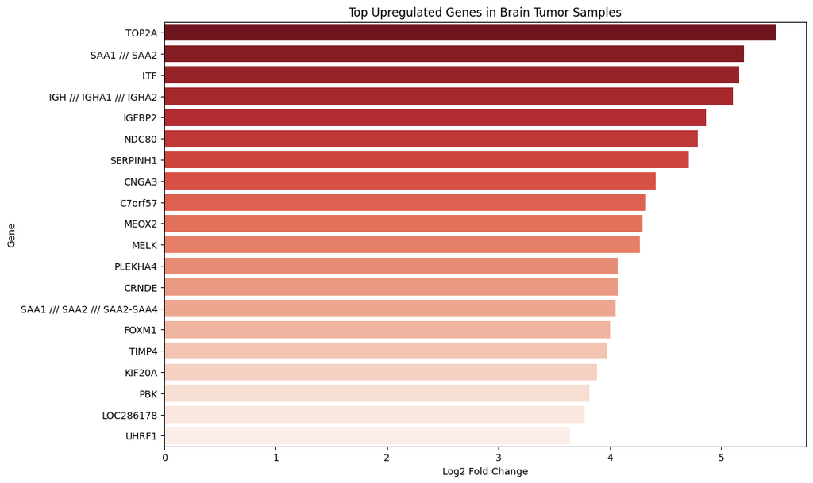

```python
# Plot top upregulated genes

plt.figure(figsize=(12, 8))

sns.barplot(

    data=top_upregulated,

    x='Log2FC',

    y='Gene',

    palette='Reds_r'
)

plt.title('Top Upregulated Genes in Brain Tumor Samples')

plt.xlabel('Log2 Fold Change')

plt.ylabel('Gene')

plt.show()
```

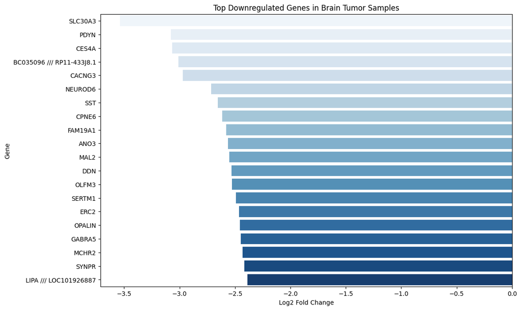

```python
# Plot top downregulated genes

plt.figure(figsize=(12, 8))

sns.barplot(

    data=top_downregulated,

    x='Log2FC',

    y='Gene',

    palette='Blues'
)

plt.title('Top Downregulated Genes in Brain Tumor Samples')

plt.xlabel('Log2 Fold Change')

plt.ylabel('Gene')

plt.show()
```

## Biological Interpretation of Differentially Expressed Biomarker Candidates

Differential expression analysis identified several highly dysregulated genes exhibiting strong statistical significance and substantial fold-change differences between tumor and non-tumor brain tissue samples.

The transcriptomic signatures observed in this analysis are biologically consistent with known mechanisms associated with aggressive brain tumor progression, particularly glioblastoma-associated molecular dysregulation.

## Upregulated Gene Signatures

Several strongly upregulated genes identified in tumor samples are known to participate in cellular proliferation, mitotic progression, DNA replication, and oncogenic signaling.

### TOP2A

`TOP2A` exhibited one of the highest expression increases within tumor samples. TOP2A encodes DNA topoisomerase II alpha, an essential enzyme involved in DNA replication and chromosomal segregation during mitosis. Elevated TOP2A expression is frequently associated with highly proliferative cancers and poor clinical prognosis.

### MELK

`MELK` (Maternal Embryonic Leucine Zipper Kinase) demonstrated strong tumor-associated overexpression. MELK is implicated in cell cycle progression, stem-cell maintenance, and tumor survival pathways, and has previously been reported as a glioblastoma-associated oncogenic regulator.

### FOXM1

`FOXM1` is a well-established transcription factor associated with tumor proliferation, cell-cycle regulation, and invasion. Increased FOXM1 expression is commonly observed in high-grade gliomas and aggressive malignancies.

### KIF20A and PBK

`KIF20A` and `PBK` are mitosis-associated genes involved in spindle formation and cell division. Their elevated expression suggests enhanced proliferative activity within tumor tissues.

### TIMP4 and SERPINH1

Genes such as `TIMP4` and `SERPINH1` are associated with extracellular matrix remodeling and tumor microenvironmental alterations, potentially contributing to invasion and pathological tissue restructuring.

Collectively, the upregulated transcriptomic profile strongly supports activation of proliferative and oncogenic pathways within brain tumor samples.

## Downregulated Gene Signatures

Several significantly downregulated genes were associated with neuronal signaling, synaptic regulation, and normal neurophysiological function.

### SLC30A3

`SLC30A3`, one of the most strongly downregulated genes, is involved in neuronal zinc transport and synaptic homeostasis. Reduced expression may reflect neuronal dysfunction and tissue disruption within tumor-associated regions.

### PDYN and SST

`PDYN` and `SST` are neuropeptide-associated genes involved in neurotransmission and neuronal communication. Their suppression suggests impairment of normal neuronal signaling pathways during tumor progression.

### NEUROD6

`NEUROD6` is a neuronal differentiation regulator implicated in neuronal survival and maturation. Downregulation of NEUROD6 may indicate loss of differentiated neuronal characteristics within malignant tissue.

### OPALIN and GABRA5

Genes such as `OPALIN` and `GABRA5` are associated with myelination and inhibitory neurotransmission. Reduced expression levels may reflect extensive disruption of normal brain tissue architecture in tumor regions.

## Overall Transcriptomic Interpretation

The observed transcriptomic alterations collectively demonstrate a clear biological transition from normal neuronal homeostasis toward highly proliferative and pathologically dysregulated tumor-associated cellular states.

Upregulated genes predominantly reflected:

- mitotic activation
- cell-cycle progression
- oncogenic signaling
- proliferative expansion
- extracellular remodeling

In contrast, downregulated genes largely represented suppression of:

- neuronal differentiation
- neurotransmission
- synaptic regulation
- normal neurophysiological function

These findings strongly support the biological validity of the transcriptomic analysis and highlight several candidate biomarkers potentially relevant to brain tumor diagnosis, prognosis, and therapeutic targeting.

# 8. Heatmap Visualization of Highly Dysregulated Genes

## Objective

Heatmap analysis was performed to visualize transcriptomic expression patterns associated with the most significantly dysregulated genes identified during differential expression analysis.

Heatmaps enable simultaneous visualization of:

- relative gene expression intensity
- clustering behavior across samples
- tumor-associated transcriptomic signatures
- separation between pathological and non-tumor tissues

Genes exhibiting strong expression differences between tumor and non-tumor groups may represent biologically relevant biomarkers associated with tumor progression and molecular dysregulation.

```python
# Select top significant genes

top_genes = significant_deg.sort_values(

    by='Adjusted_P_Value'
).head(50)

top_gene_names = top_genes['Gene'].tolist()
```

```python
# Remove duplicate genes if present

top_gene_names = list(dict.fromkeys(top_gene_names))
```

```python
# Extract expression matrix

heatmap_data = gene_expression_df.loc[

    top_gene_names,
    :
]

print(heatmap_data.shape)
```

```
(50, 180)
```

```python
# Manual Z-score normalization

heatmap_zscore = heatmap_data.sub(

    heatmap_data.mean(axis=1),

    axis=0

).div(

    heatmap_data.std(axis=1),

    axis=0
)

print(type(heatmap_zscore))

print(heatmap_zscore.shape)
```

```
<class 'pandas.core.frame.DataFrame'>
(50, 180)
```

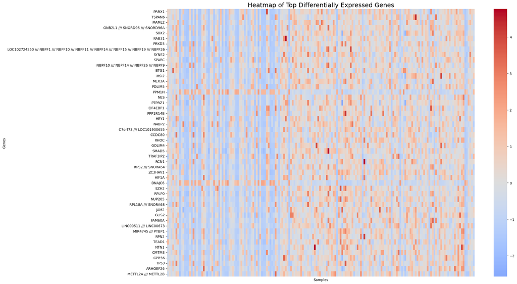

```python
plt.figure(figsize=(20, 14))

sns.heatmap(

    heatmap_zscore,

    cmap='coolwarm',

    center=0,

    xticklabels=False,

    yticklabels=True
)

plt.title(

    'Heatmap of Top Differentially Expressed Genes',

    fontsize=18
)

plt.xlabel('Samples')

plt.ylabel('Genes')

plt.show()
```

## Interpretation of Differential Expression Heatmap

The heatmap visualization demonstrates distinct transcriptomic expression patterns across the most significantly dysregulated genes identified during differential expression analysis.

Several genes exhibited coordinated upregulation across tumor-associated samples, while others demonstrated pronounced downregulation relative to non-tumor controls. The observed expression gradients indicate substantial molecular heterogeneity and widespread transcriptional remodeling associated with brain tumor pathology.

The strong contrast between highly expressed and suppressed genes supports the presence of biologically meaningful transcriptomic separation between pathological and non-pathological tissue states.

Genes exhibiting elevated expression across tumor samples are likely associated with:

- proliferative signaling
- mitotic progression
- oncogenic activation
- extracellular matrix remodeling
- tumor invasion pathways

Conversely, suppressed genes predominantly correspond to neuronal signaling and neurophysiological maintenance pathways, suggesting progressive disruption of normal brain tissue function during tumor development.

Overall, the heatmap provides visual confirmation of robust transcriptomic dysregulation within tumor-associated samples and further supports the biological validity of the identified differential gene expression signatures.

# 9. Principal Component Analysis (PCA) of Transcriptomic Profiles

## Objective

Principal Component Analysis (PCA) was performed to investigate global transcriptomic variation across tumor and non-tumor samples.

PCA is a dimensionality reduction technique that transforms high-dimensional gene expression data into lower-dimensional representations while preserving the major sources of biological variance.

The analysis enables visualization of:

- transcriptomic clustering behavior
- molecular similarity between samples
- separation between pathological and control tissues
- dominant variance structures within the dataset

Distinct clustering of tumor and non-tumor samples would indicate strong transcriptomic divergence associated with brain tumor pathology.

```python
from sklearn.decomposition import PCA
from sklearn.preprocessing import StandardScaler
```

```python
# Transpose expression matrix

pca_data = gene_expression_df.T

print(pca_data.shape)
```

```
(180, 22497)
```

- rows = samples
- columns = genes

```python
# Standardize data

scaler = StandardScaler()

scaled_data = scaler.fit_transform(pca_data)
```

```python
# PCA transformation

pca = PCA(n_components=2)

pca_result = pca.fit_transform(scaled_data)
```

```python
# Create PCA dataframe

pca_df = pd.DataFrame({

    'PC1': pca_result[:, 0],

    'PC2': pca_result[:, 1],

    'Condition': [

        'Non-Tumor'

        if 'non-tumor' in col.lower()

        else 'Tumor'

        for col in pca_data.index
    ]
})

pca_df.head()
```

|  | PC1 | PC2 | Condition |
| --- | --- | --- | --- |
| 0 | 8.811142 | 88.934087 | Tumor |
| 1 | -9.772682 | 10.910219 | Tumor |
| 2 | 61.050610 | 24.638578 | Tumor |
| 3 | -73.464659 | -32.076424 | Tumor |
| 4 | 0.040097 | -2.436289 | Tumor |

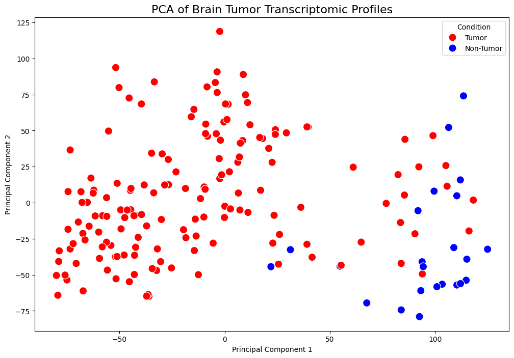

```python
plt.figure(figsize=(12, 8))

sns.scatterplot(

    data=pca_df,

    x='PC1',

    y='PC2',

    hue='Condition',

    palette={

        'Tumor': 'red',

        'Non-Tumor': 'blue'
    },

    s=120
)

plt.title(

    'PCA of Brain Tumor Transcriptomic Profiles',

    fontsize=16
)

plt.xlabel('Principal Component 1')

plt.ylabel('Principal Component 2')

plt.legend(title='Condition')

plt.show()
```

## Interpretation of Principal Component Analysis (PCA)

Principal Component Analysis revealed substantial transcriptomic divergence between tumor and non-tumor brain tissue samples.

The PCA projection demonstrates that non-tumor samples form a relatively distinct cluster primarily separated along the first principal component (PC1), whereas tumor-associated samples exhibit broader spatial dispersion and increased transcriptomic heterogeneity.

This separation pattern indicates that the dominant sources of variance within the gene expression dataset are strongly associated with pathological tumor status.

Several important biological observations can be inferred from the PCA distribution:

- non-tumor samples exhibit comparatively consistent transcriptomic organization
- tumor samples display substantially greater molecular heterogeneity
- transcriptomic dysregulation contributes strongly to overall variance structure
- pathological samples demonstrate complex molecular diversity characteristic of brain tumor progression

The broader spread of tumor-associated samples is biologically plausible because brain tumors, particularly glioblastomas and mixed glioma subtypes, frequently exhibit:

- heterogeneous cellular composition
- variable proliferative activity
- differential oncogenic pathway activation
- microenvironmental diversity
- inter-patient molecular variability

Although partial overlap exists between certain tumor and non-tumor samples, the overall clustering behavior demonstrates clear transcriptomic distinction between pathological and control tissues.

The PCA results therefore provide strong validation that the differential gene expression pipeline successfully captured biologically meaningful molecular alterations associated with brain tumor pathology.

# 10. Functional Enrichment and Pathway Analysis

## Objective

To investigate the biological significance of the identified differentially expressed genes, functional enrichment analysis was performed using significantly dysregulated transcriptomic biomarkers.

Pathway enrichment analysis enables identification of:

- dysregulated biological pathways
- molecular signaling networks
- cancer-associated cellular processes
- functional gene ontology categories

The analysis provides biological interpretation of transcriptomic alterations observed in tumor-associated samples and helps identify pathways potentially contributing to brain tumor progression, proliferation, invasion, and pathological remodeling.

```python
# Export significant DEGs

significant_deg.to_csv(

    'significant_brain_tumor_DEGs.csv',

    index=False
)

print("DEG file exported successfully.")
```

```
DEG file exported successfully.
```

```python
# Export top downregulated genes

top_downregulated.to_csv(

    'top_downregulated_genes.csv',

    index=False
)
```

```python
# Export only gene symbols

significant_deg['Gene'].to_csv(

    'significant_gene_symbols.txt',

    index=False,

    header=False
)

print("Gene symbol file exported successfully.")
```

```
Gene symbol file exported successfully.
```

```python
# Keep only first gene symbol before "///"

significant_deg['Clean_Gene'] = significant_deg['Gene'].apply(

    lambda x: str(x).split('///')[0].strip()
)
```

```python
# Remove empty gene names

significant_deg = significant_deg[

    significant_deg['Clean_Gene'] != ''
]
```

```python
significant_deg.head(10)
```

|  | Gene | Tumor_Mean | NonTumor_Mean | Log2FC | P_Value | Adjusted_P_Value | Clean_Gene |
| --- | --- | --- | --- | --- | --- | --- | --- |
| 11 | AACS | 888.185350 | 1982.021739 | -1.158040 | 8.446797e-09 | 4.176431e-08 | AACS |
| 17 | AAED1 | 465.885987 | 229.382609 | 1.022221 | 1.144933e-14 | 1.511593e-13 | AAED1 |
| 19 | AAK1 | 605.459327 | 1271.071429 | -1.069943 | 7.156130e-14 | 8.345850e-13 | AAK1 |
| 29 | AASS | 531.511465 | 246.204348 | 1.110245 | 6.355471e-12 | 5.505546e-11 | AASS |
| 31 | AATK | 1261.120382 | 3408.330435 | -1.434359 | 5.666956e-05 | 1.526089e-04 | AATK |
| 32 | AB074162 /// MIR181A2HG | 291.134395 | 68.008696 | 2.097894 | 4.820281e-10 | 3.006428e-09 | AB074162 |
| 35 | ABCA1 | 1784.457803 | 487.434783 | 1.872205 | 1.747714e-25 | 1.191464e-23 | ABCA1 |
| 38 | ABCA13 | 30.045860 | 6.844928 | 2.134059 | 3.908649e-05 | 1.076026e-04 | ABCA13 |
| 40 | ABCA2 | 801.156900 | 1749.808696 | -1.127040 | 2.312804e-06 | 7.708319e-06 | ABCA2 |
| 46 | ABCA8 | 517.769002 | 1141.178261 | -1.140144 | 1.187794e-02 | 2.165461e-02 | ABCA8 |

```python
# Export cleaned gene symbols

significant_deg['Clean_Gene'].to_csv(

    'cleaned_significant_genes.txt',

    index=False,

    header=False
)

print("Cleaned gene list exported.")
```

```
Cleaned gene list exported.
```

# Enrichr Analysis

```python
import pandas as pd

# Example: Load KEGG enrichment results
kegg_df = pd.read_csv(
    "/kaggle/input/datasets/somshirsha/enrichr-analysis/KEGG_2026_table (1).txt",
    sep="\t"
)

# Display top pathways
kegg_df.head(10)
```

|  | Term | Overlap | P-value | Adjusted P-value | Old P-value | Old Adjusted P-value | Odds Ratio | Combined Score | Genes |
| --- | --- | --- | --- | --- | --- | --- | --- | --- | --- |
| 0 | MORPHINE ADDICTION | 35/89 | 1.679371e-10 | 4.318699e-08 | 0 | 0 | 4.553495 | 102.487488 | GABRB3;GABRB2;GABRB1;PDE1C;PDE1B;PDE1A;GNAI3;C... |
| 1 | GABAERGIC SYNAPSE | 34/86 | 2.578328e-10 | 4.318699e-08 | 0 | 0 | 4.592202 | 101.389902 | GABRB3;GABRB2;GABRB1;GLS2;GNAI3;CACNA1B;CACNA1... |
| 2 | NEUROACTIVE LIGAND SIGNALING | 53/195 | 2.926668e-08 | 3.268113e-06 | 0 | 0 | 2.627981 | 45.587111 | GABRB3;GABRB2;CHRM3;GABRB1;CHRM1;HTR2C;HTR2A;A... |
| 3 | GLUTAMATERGIC SYNAPSE | 36/112 | 5.046805e-08 | 3.883278e-06 | 0 | 0 | 3.324958 | 55.865689 | GLS2;ITPR1;GNAI3;CACNA1C;ADCY1;SLC1A6;GRM1;GNA... |
| 4 | CELL CYCLE | 45/157 | 5.795937e-08 | 3.883278e-06 | 0 | 0 | 2.824695 | 47.069372 | PCNA;MCM7;CDCA5;BUB1B;TTK;AURKB;CDC20;CCNB2;CC... |
| 5 | ECM-RECEPTOR INTERACTION | 30/88 | 1.500544e-07 | 8.378038e-06 | 0 | 0 | 3.625683 | 56.967705 | LAMA5;ITGB4;LAMA4;LAMC1;HMMR;LMNB2;COMP;SV2C;R... |
| 6 | CELLULAR SENESCENCE | 43/156 | 3.752556e-07 | 1.795866e-05 | 0 | 0 | 2.672949 | 39.548045 | TRAF3IP2;SERPINE1;ITPR1;FOXM1;ETS1;ZFP36L2;CCN... |
| 7 | HUMAN T-CELL LEUKEMIA VIRUS 1 INFECTION | 53/219 | 1.601553e-06 | 6.033173e-05 | 0 | 0 | 2.244921 | 29.957434 | NRP1;SPI1;ITGB2;BUB1B;ETS1;CDC20;PPP3CA;PPP3CB... |
| 8 | SYNAPTIC VESICLE CYCLE | 26/78 | 1.620853e-06 | 6.033173e-05 | 0 | 0 | 3.500402 | 46.669308 | SNAP25;RAB3A;STXBP1;CACNA1B;TCIRG1;CPLX2;SLC1A... |
| 9 | MICRORNAS IN CANCER | 42/160 | 2.077616e-06 | 6.960012e-05 | 0 | 0 | 2.498431 | 32.690197 | NOTCH1;SHC1;GLS2;CDCA5;EFNA4;HOXD10;EGFR;CCND2... |

```python
display(
    kegg_df[
        ['Term', 'Adjusted P-value', 'Combined Score']
    ].head(10)
)
```

|  | Term | Adjusted P-value | Combined Score |
| --- | --- | --- | --- |
| 0 | MORPHINE ADDICTION | 4.318699e-08 | 102.487488 |
| 1 | GABAERGIC SYNAPSE | 4.318699e-08 | 101.389902 |
| 2 | NEUROACTIVE LIGAND SIGNALING | 3.268113e-06 | 45.587111 |
| 3 | GLUTAMATERGIC SYNAPSE | 3.883278e-06 | 55.865689 |
| 4 | CELL CYCLE | 3.883278e-06 | 47.069372 |
| 5 | ECM-RECEPTOR INTERACTION | 8.378038e-06 | 56.967705 |
| 6 | CELLULAR SENESCENCE | 1.795866e-05 | 39.548045 |
| 7 | HUMAN T-CELL LEUKEMIA VIRUS 1 INFECTION | 6.033173e-05 | 29.957434 |
| 8 | SYNAPTIC VESICLE CYCLE | 6.033173e-05 | 46.669308 |
| 9 | MICRORNAS IN CANCER | 6.960012e-05 | 32.690197 |

# KEGG Pathway Enrichment Analysis

The significantly dysregulated genes were subjected to KEGG pathway enrichment analysis using the Enrichr platform to identify molecular pathways associated with brain tumor progression.

The enrichment analysis revealed strong associations with:

- GABAergic synapse signaling
- Glutamatergic synapse pathways
- Cell-cycle regulation
- ECM-receptor interaction
- Neuroactive ligand-receptor signaling

These findings indicate that the tumor transcriptomic profile is characterized by:

- abnormal neuronal signaling,
- uncontrolled proliferative activity,
- extracellular matrix remodeling,
- and dysregulated neurodevelopmental programs.

The enrichment of synaptic signaling pathways suggests active neuron–tumor communication mechanisms, which are increasingly recognized in glioma biology.

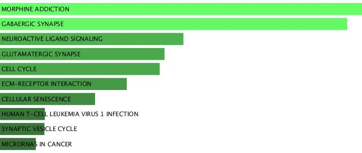

```python
from IPython.display import Image, display

display(Image("/kaggle/input/datasets/somshirsha/enrichr-images/KEGG_2026_bar_graph.jpg"))
```

# KEGG Pathway Visualization

The bar plot below illustrates the top enriched KEGG pathways identified from the significant differentially expressed genes.

Notably, pathways associated with:

- synaptic signaling,
- cell-cycle regulation,
- extracellular matrix interaction,
- and neuronal communication

were strongly enriched, indicating complex molecular mechanisms underlying glioma progression and tumor microenvironment remodeling.

```python
import pandas as pd

# Example: Load Disease enrichment results
dis_df = pd.read_csv(
    "/kaggle/input/datasets/somshirsha/enrichr-analysis/DisGeNET_table.txt",
    sep="\t"
)

# Display top pathways
dis_df.head(10)
```

|  | Term | Overlap | P-value | Adjusted P-value | Old P-value | Old Adjusted P-value | Odds Ratio | Combined Score | Genes |
| --- | --- | --- | --- | --- | --- | --- | --- | --- | --- |
| 0 | Glioma | 435/2211 | 5.115373e-24 | 4.342440e-20 | 0 | 0 | 1.848822 | 99.151941 | MAML2;MYT1L;GMFG;SERPINE1;SPINT2;ENO2;SMC4;SOX... |
| 1 | Schizophrenia | 378/1923 | 1.119893e-20 | 4.753385e-17 | 0 | 0 | 1.823966 | 83.790195 | FAAH;OXTR;VIPR2;MYT1L;STMN2;ICAM3;ENO2;ABCA13;... |
| 2 | Glioblastoma | 379/1937 | 2.258346e-20 | 6.390368e-17 | 0 | 0 | 1.812900 | 82.010301 | TRIO;SPARC;HHIP;SERPINE1;SPINT2;MKI67;ENO2;GLS... |
| 3 | Neoplasm Metastasis | 659/3920 | 3.643247e-18 | 7.731880e-15 | 0 | 0 | 1.547797 | 62.149698 | MAML2;SERPINE1;SPINT2;ACCS;ENO2;SMC4;LIPA;RXFP... |
| 4 | Tumor Progression | 391/2090 | 1.448160e-17 | 2.458686e-14 | 0 | 0 | 1.709500 | 66.283548 | CYFIP2;SPI1;SERPINE1;DCAF6;MIR424;MYC;STMN1;PR... |
| 5 | Liver Cirrhosis, Experimental | 184/801 | 7.567301e-17 | 1.070647e-13 | 0 | 0 | 2.156959 | 80.066568 | FAM49A;VIPR1;SPARC;GMFG;PLOD2;PLAT;SMC5;IFI35;... |
| 6 | Glioblastoma Multiforme | 191/854 | 3.418536e-16 | 4.145707e-13 | 0 | 0 | 2.084245 | 74.224431 | EPHB6;SPARC;MYT1L;HP;TNC;BUB1B;MKI67;CTGF;GLS;... |
| 7 | oligodendroglioma | 65/183 | 1.094231e-15 | 1.161116e-12 | 0 | 0 | 3.902904 | 134.450055 | CNTNAP2;CNTNAP1;NXT1;MYT1L;ADM;MKI67;SOX2;RIMS... |
| 8 | Mammary Neoplasms | 426/2387 | 1.583803e-15 | 1.493878e-12 | 0 | 0 | 1.613472 | 54.985421 | SERPINE1;SPINT2;ELK3;GLS;MIR424;MYC;STMN1;HOXA... |
| 9 | Well Differentiated Oligodendroglioma | 63/176 | 1.966347e-15 | 1.669232e-12 | 0 | 0 | 3.948111 | 133.693307 | CNTNAP2;CNTNAP1;NXT1;MYT1L;ADM;MKI67;SOX2;RIMS... |

# Disease Enrichment Analysis

Disease enrichment analysis using DisGeNET demonstrated strong enrichment for glioma-associated disease signatures.

The top enriched disease terms included:

- Glioma
- Glioblastoma
- Tumor Progression
- Oligodendroglioma
- Neoplasm Metastasis

The enrichment of these disease categories validates the biological relevance of the identified differentially expressed genes and confirms successful capture of glioma-associated molecular patterns.

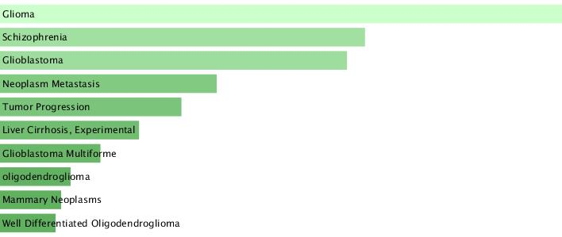

```python
from IPython.display import Image, display

display(Image("/kaggle/input/datasets/somshirsha/enrichr-images/DisGeNET_bar_graph.jpg"))
```

# Disease Enrichment Analysis

Disease enrichment analysis demonstrated strong association between the identified transcriptomic signatures and known glioma-related pathological conditions.

The top enriched disease categories included:

- Glioma
- Glioblastoma
- Tumor Progression
- Oligodendroglioma
- Neoplasm Metastasis

The strong enrichment of glioma and glioblastoma disease signatures validates the biological relevance of the differential gene expression analysis and confirms that the identified molecular alterations are highly consistent with established brain tumor biology.

Additionally, enrichment of tumor progression and metastatic processes suggests activation of molecular pathways associated with:

- aggressive tumor growth,
- invasive behavior,
- extracellular remodeling,
- and pathological tissue transformation.

These findings provide strong evidence that the transcriptomic analysis successfully captured biologically meaningful molecular mechanisms underlying brain tumor development and progression.

```python
import pandas as pd

# Example: Load Reactome enrichment results
reactome_df = pd.read_csv(
    "/kaggle/input/datasets/somshirsha/enrichr-analysis/Reactome_Pathways_2024_table.txt",
    sep="\t"
)

# Display top pathways
reactome_df.head(10)
```

|  | Term | Overlap | P-value | Adjusted P-value | Old P-value | Old Adjusted P-value | Odds Ratio | Combined Score | Genes |
| --- | --- | --- | --- | --- | --- | --- | --- | --- | --- |
| 0 | Neuronal System | 128/411 | 1.406300e-23 | 2.403367e-20 | 0 | 0 | 3.257939 | 171.427830 | KCNG3;RAB3A;IL1RAP;GLS;RIMS1;GRIP1;TUBB6;PPFIA... |
| 1 | Transmission Across Chemical Synapses | 87/269 | 1.455201e-17 | 1.243469e-14 | 0 | 0 | 3.404996 | 132.007634 | GABRB3;GABRB2;SNAP25;GABRB1;RAB3A;RASGRF2;KIF1... |
| 2 | Extracellular Matrix Organization | 86/300 | 6.299420e-14 | 3.588569e-11 | 0 | 0 | 2.856082 | 86.812722 | DDR1;SPARC;ITGB4;ELN;SERPINE1;ITGB2;TNC;ICAM3;... |
| 3 | Neurotransmitter Receptors and Postsynaptic Si... | 61/204 | 4.083947e-11 | 1.744866e-08 | 0 | 0 | 3.013120 | 72.077966 | GABRB3;GABRB2;GABRB1;RASGRF2;KIF17;NRGN;GRIP1;... |
| 4 | ECM Proteoglycans | 31/76 | 6.274683e-10 | 2.144687e-07 | 0 | 0 | 4.834420 | 102.438108 | LAMA5;SPARC;LAMA4;SERPINE1;TNC;LAMC1;HAPLN1;CO... |
| 5 | Signal Transduction | 426/2613 | 1.459494e-09 | 4.157125e-07 | 0 | 0 | 1.425676 | 29.005627 | CYFIP2;NUP107;TRIO;MAML2;SERPINE1;STMN2;SPINT2... |
| 6 | Protein-protein Interactions at Synapses | 33/88 | 2.348129e-09 | 5.732789e-07 | 0 | 0 | 4.211599 | 83.682983 | STXBP1;NRXN3;IL1RAP;GRM1;BEGAIN;GRM5;GRIN2A;EP... |
| 7 | GABA Receptor Activation | 26/60 | 3.189659e-09 | 6.813910e-07 | 0 | 0 | 5.359083 | 104.841633 | GABRB3;GABRB2;GABRB1;GNAI3;ADCY1;GNAI1;ADCY5;G... |
| 8 | Collagen Formation | 33/90 | 4.562885e-09 | 8.664412e-07 | 0 | 0 | 4.063357 | 78.038037 | COL15A1;CD151;PCOLCE2;ITGB4;COL11A1;PLOD2;LOXL... |
| 9 | Assembly of Collagen Fibrils and Other Multime... | 25/61 | 2.514594e-08 | 3.945424e-06 | 0 | 0 | 4.864178 | 85.116152 | COL15A1;CD151;ITGB4;COL11A1;LOXL1;LOXL2;MMP7;C... |

# Reactome Pathway Analysis

Reactome enrichment analysis identified major alterations in neuronal and extracellular matrix-related pathways.

The most significant pathways included:

- Neuronal System
- Synaptic Transmission
- Extracellular Matrix Organization
- Signal Transduction

These pathways suggest that tumor-associated molecular dysregulation affects both neuronal communication and tissue structural organization, which may contribute to tumor invasion and imaging heterogeneity observed in MRI scans.

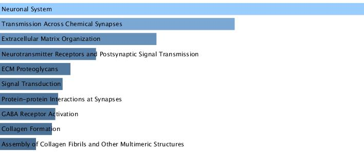

```python
display(Image("/kaggle/input/datasets/somshirsha/enrichr-images/Reactome_Pathways_2024_bar_graph.jpg"))
```

# Reactome Pathway Analysis

Reactome pathway enrichment analysis revealed significant dysregulation of neuronal system pathways and extracellular matrix-associated biological processes within tumor samples.

The most strongly enriched pathways included:

- Neuronal System
- Transmission Across Chemical Synapses
- Extracellular Matrix Organization
- Signal Transduction
- GABA Receptor Activation

These pathway enrichments indicate that brain tumor progression is associated with widespread alterations in neuronal signaling, synaptic communication, and extracellular matrix remodeling.

Extracellular matrix organization is particularly important because ECM remodeling contributes to:

- tumor invasion,
- tissue restructuring,
- cellular migration,
- and increased structural heterogeneity.

The enrichment of neuronal signaling pathways further supports emerging evidence that glioma cells actively interact with neuronal networks and exploit synaptic communication pathways to promote tumor survival and progression.

Overall, the Reactome analysis demonstrates that glioma-associated transcriptomic dysregulation extends across both structural and neurophysiological biological systems.

```python
import pandas as pd

# Example: Load GO enrichment results
go_df = pd.read_csv(
    "/kaggle/input/datasets/somshirsha/enrichr-analysis/GO_Biological_Process_2026_table.txt",
    sep="\t"
)

# Display top pathways
go_df.head(10)
```

|  | Term | Overlap | P-value | Adjusted P-value | Old P-value | Old Adjusted P-value | Odds Ratio | Combined Score | Genes |
| --- | --- | --- | --- | --- | --- | --- | --- | --- | --- |
| 0 | Chemical Synaptic Transmission (GO:0007268) | 96/268 | 7.984457e-23 | 3.819764e-19 | 0 | 0 | 3.992773 | 203.160138 | GABRB3;GABRB2;CHRM3;SNAP25;GABRB1;CHRM1;DOC2A;... |
| 1 | Nervous System Development (GO:0007399) | 144/531 | 5.311272e-20 | 1.270456e-16 | 0 | 0 | 2.681988 | 119.031623 | CHRM3;SH3GL3;CHRM1;MYT1L;GDA;AVIL;ROGDI;MSI1;M... |
| 2 | Anterograde Trans-Synaptic Signaling (GO:0098916) | 65/175 | 8.422887e-17 | 1.343170e-13 | 0 | 0 | 4.188680 | 155.035586 | CHRM3;GABRB2;SNAP25;CHRM1;DOC2A;HTR2C;HTR2A;EL... |
| 3 | Synapse Organization (GO:0050808) | 54/166 | 1.511440e-11 | 1.807683e-08 | 0 | 0 | 3.402025 | 84.762724 | TENM2;CDH9;SLC8A2;GRM5;PPFIA4;PPFIA2;KIRREL3;F... |
| 4 | Synaptic Vesicle Exocytosis (GO:0016079) | 24/44 | 3.092240e-11 | 2.958655e-08 | 0 | 0 | 8.409631 | 203.509201 | SYT5;SNAP25;SYT4;UNC13C;RAB3A;UNC13A;DOC2A;SYT... |
| 5 | Modulation of Chemical Synaptic Transmission (... | 48/144 | 7.718494e-11 | 6.154213e-08 | 0 | 0 | 3.522690 | 82.025201 | CHRNA1;PXK;TRIO;MCTP1;CLSTN2;CLSTN3;CAMK2A;CAC... |
| 6 | Central Nervous System Development (GO:0007417) | 76/294 | 4.093373e-10 | 2.797528e-07 | 0 | 0 | 2.466942 | 53.326615 | SH3GL3;CNTNAP2;ROGDI;CHD7;MAST1;AATK;MSI1;MSI2... |
| 7 | Regulation of Neuron Projection Development (G... | 53/179 | 1.124301e-09 | 6.723322e-07 | 0 | 0 | 2.964426 | 61.085268 | DDR1;AVIL;STMN2;TSKU;ARHGAP44;MDK;DPYSL3;NCS1;... |
| 8 | Generation of Neurons (GO:0048699) | 58/206 | 1.580064e-09 | 8.398915e-07 | 0 | 0 | 2.763970 | 56.014062 | NRP1;MYT1L;SIX1;SOX21;SOX2;SOX3;SIX4;SOX4;EMX1... |
| 9 | Neuron Differentiation (GO:0030182) | 57/203 | 2.433692e-09 | 1.164278e-06 | 0 | 0 | 2.752723 | 54.597108 | ATP8A2;MYT1L;SOX21;SOX2;SOX3;SOX4;EPHA5;EMX1;M... |

# Gene Ontology Biological Process Analysis

Gene Ontology enrichment analysis revealed significant dysregulation of neurodevelopmental and synaptic biological processes.

These findings indicate that glioma-associated transcriptional alterations may influence neuronal signaling pathways and developmental programs involved in tumor progression.

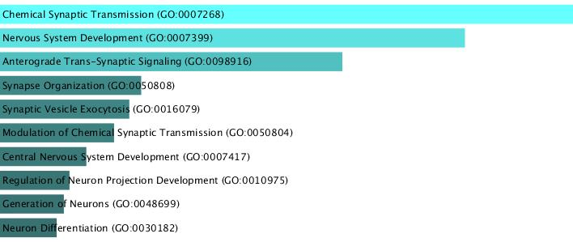

```python
display(Image("/kaggle/input/datasets/somshirsha/enrichr-images/GO_Biological_Process_2026_bar_graph.jpg"))
```

# Gene Ontology Biological Process Analysis

The Gene Ontology Biological Process enrichment plot highlights the major biological functions significantly associated with the differentially expressed genes identified in brain tumor samples.

Several enriched biological processes were strongly related to:

- synaptic signaling,
- neuronal communication,
- nervous system development,
- neuron differentiation,
- and synapse organization.

The enrichment of chemical synaptic transmission and neuronal developmental pathways suggests that glioma-associated molecular dysregulation extensively affects normal neurophysiological signaling mechanisms.

Additionally, the observed alterations in neuron differentiation and synaptic organization pathways may reflect progressive disruption of normal brain tissue architecture during tumor progression.

These findings support the hypothesis that glioma development involves not only uncontrolled proliferation but also substantial remodeling of neuronal communication networks and neurodevelopmental regulatory pathways.